# **t-Distributed Stochastic Neighbor Embedding (t-SNE)**

1. **Introduction**
- t-Distributed Stochastic Neighbor Embedding (t-SNE) is a powerful **nonlinear dimensionality reduction** technique specifically designed for visualizing high-dimensional data. Developed in 2008 by Laurens van der Maaten and Geoffrey Hinton, t-SNE has become one of the most widely used algorithms for data visualization in machine learning and data science. The technique **excels at preserving local structure** in data while **revealing global patterns** such as clusters, making it particularly valuable for exploratory data analysis.
- Unlike linear dimensionality reduction methods such as Principal Component Analysis (PCA), t-SNE employs a **nonlinear approach** that focuses on **maintaining pairwise similarities between data points rather than preserving variance**. This fundamental difference allows t-SNE to uncover complex relationships and patterns that would otherwise remain hidden in high-dimensional space.
2. **Theoretical Foundation**
- **“Preserving the local relationships between points”** in the context of t-SNE refers to maintaining the relative distances and similarities between neighboring data points when they are mapped from a high-dimensional space to a lower-dimensional space.
- t-SNE achieves this by **measuring the similarity between data points in the high-dimensional space and representing this similarity as probabilities**. Then, it constructs a similar probability distribution in the lower-dimensional space and minimizes the difference between the two distributions using a technique called gradient descent. This process allows t-SNE to effectively capture the local structure of the data
3. **Intuition – how to calculate the “similarity” between points**
1. One approach is to compute the distance between points, but this method becomes **less reliable in higher dimensions due to the “curse of dimensionality.”** Instead of relying solely on distance calculations, t-SNE utilizes a probabilistic approach. For each data point, such as x1, a Gaussian distribution is plotted around it with a mean of zero, and the standard deviation is determined based on the **density** of nearby points around x1.
2. Now, on the x-axis, we consider distances from the reference point, such as x1. For each point in the dataset, we calculate its distance to x1 and plot these distances along the x-axis. The y-axis represents the corresponding probability density, allowing us to determine the **scaled** probability of each data point relative to x1, which serves as the similarity score for that point.
3. Similarly, this method is applied to each point in the dataset, resulting in an **n * n matrix** where the similarity score for each data point is recorded relative to every other data point. Due to the unique distribution around each point (due to different **density of points)**, the probability of point x1 to x2 (**P(x1 | x2)**) is **not necessarily equal** to the probability of x2 to x1 (**P(x2 | x1)**). High value of P between two points means they are similar to each other while low value indicates that they are dissimilar points.

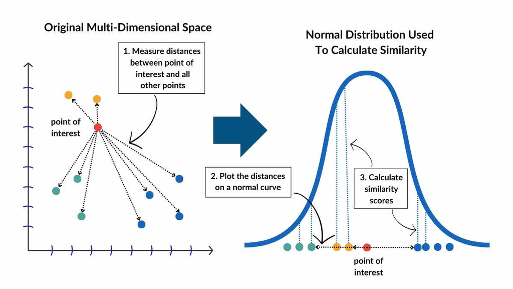

4. Now we reduce the higher dimension into lower dimension and points are randomly distributed on x -axis.
5. At this stage, we recalculate the similarity score for each point relative to others, resulting in another n * n matrix. We now have two matrices: one representing the similarity scores in the higher dimension and another representing the similarity scores in the lower dimension.
6. To preserve the local relationships between points, ensuring that neighboring points remain close in the lower dimension, we aim to align the lower-dimensional matrix with the higher-dimensional one. This alignment involves adjusting the position of points iteratively until the similarity matrix in the lower dimension resembles the one in the higher dimension as closely as possible.

[figure not shown]

7. **NOTE**: an alternative way to find the scaled probability is as follows- start with a gaussian distribution with mean 0 and standard deviation 1 plotted around the reference point, next evaluate the **unscaled** probability as described in point(ii). Now divide all the **unscaled** probabilities with respect to the reference by the **sum** of all the **unscaled** probabilities with respect to that reference. This gives the **scaled** probabilities.
4. **Mathematical Foundation**
   1. **Computing Similarities-**
- **Gaussian Distribution in High-Dimensional Space**  
  The t-SNE algorithm operates by modeling similarities between data points as probability distributions in both high-dimensional and low-dimensional spaces. In the high-dimensional space, conditional probabilities are computed using a Gaussian distribution, where the conditional probability $p_{j|i}$ represents the likelihood that datapoint $x_{i}$ would select $x_{j}$ as its neighbor.

The mathematical formulation for high-dimensional similarities is given by:

$$p_{j\text{|}i} = \frac{\exp\left( -
\left| x_{i} - x_{j} \right|^{2}\text{/}2\sigma_{i}^{2} \right)}{\sum_{k
\neq i}^{}{\exp\left( - \left| x_{i} - x_{k}
\right|^{2}\text{/}2\sigma_{i}^{2} \right)}}$$

where $\sigma_{i}$ represents the variance of the Gaussian distribution centered on datapoint $x_{i}$.

A key innovation of t-SNE is its use of a **student-t distribution** with **one degree of freedom** (**equivalent to a Cauchy distribution**) to model similarities in the low-dimensional embedding space. This choice addresses the "crowding problem" that affects many dimensionality reduction techniques. Similarity is determined in a similar way to what is done in High-Dimensional Space.

The low-dimensional similarities are computed as:

$$q_{j\text{|}i} = \frac{\left( 1 + \left|
y_{i} - y_{j} \right|^{2} \right)^{- 1}}{\sum_{k \neq i}^{}\left( 1 +
\left| y_{i} - y_{k} \right|^{2} \right)^{- 1}}$$

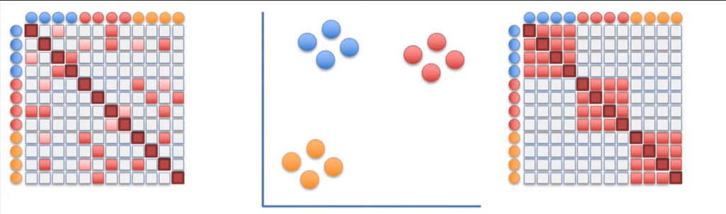

The heavy-tailed nature of the student-t distribution allows moderate distances in high-dimensional space to be represented by much larger distances in the low-dimensional map, effectively preventing points from crowding together at the center of the visualization.

The Optimization step involves transforming the Low Dimensional similarity as effectively as possible to match the High Dimensional similarity

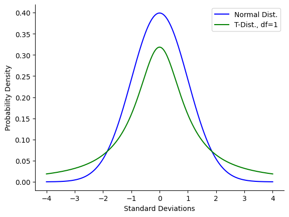

1. **Perplexity Parameter-**
- A crucial hyperparameter in t-SNE is perplexity, which effectively controls the number of nearest neighbors each point considers during the dimensionality reduction process, basically the **density** parameter. Perplexity is defined mathematically as:

$$Perp\left( P_{i} \right) = 2^{H\left(
P_{i} \right)}$$

where $H\left( P_{i} \right)$ represents the **Shannon entropy** of the probability distribution $P_{i}$.The algorithm performs a binary search to find the appropriate variance $\sigma_{i}$ that achieves the desired perplexity for each datapoint. Typical perplexity values range from 5 to 50, with common practice suggesting values between 30 and 50 for most applications.

- **Shannon entropy**, introduced by Claude Shannon, is a measure of uncertainty or randomness associated with a random variable. It quantifies the average amount of information needed to describe an outcome of that variable. In essence, it quantifies how unpredictable a system is.

$$H = - \text{Σ}\left\lbrack p\left( x_{i}
\right)*log_{2}\left( p\left( x_{i} \right) \right)
\right\rbrack\,$$

where:

$x_{i}$ represents each possible outcome of the random variable.

$p\left( x_{i} \right)$ is the probability of the outcome xi.

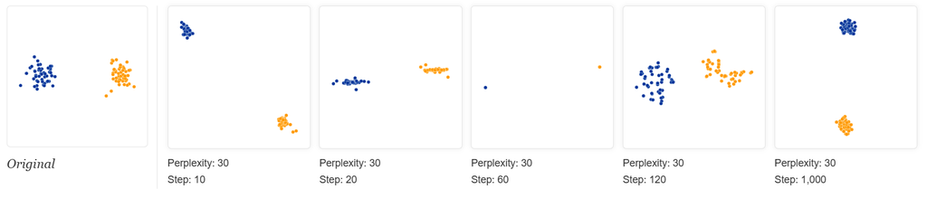

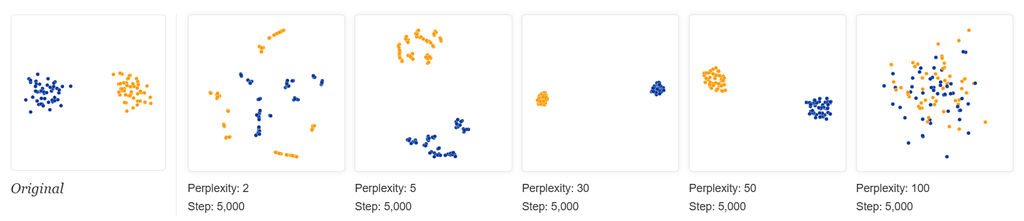

The summation is performed over all possible outcomes. The base of the logarithm (usually 2) determines the units of entropy

5. **Algorithm Design and Implementation**

**5.1 Core Algorithm Steps**

- The t-SNE algorithm follows a systematic optimization procedure that **minimizes the Kullback-Leibler (KL) divergence** between the high-dimensional and low-dimensional probability distributions. The cost function, which is also the **Kullback-Leibler (KL) divergence** is defined as:

$$C =
\sum_{i}^{}{\sum_{j}^{}p_{j\text{|}i}\log\left(
\frac{p_{j\text{|}i}}{q_{j\text{|}i}} \right)}$$

where $p_{j\text{|}i}$ represents the joint probabilities in high-dimensional space and $q_{j\text{|}i}$ represents the joint probabilities in low-dimensional space.

- The optimization process involves iterative gradient descent with the gradient given by:

$$\frac{\delta C}{\delta y_{i}} =
4\sum_{j}^{}{\left( p_{j\text{|}i} - q_{j\text{|}i} \right)\left( y_{i}
- y_{j} \right)\left( 1 + \left| y_{i} - y_{j} \right|^{2} \right)^{-
1}}$$

This gradient can be interpreted as a system of springs between map points, where attractive and repulsive forces depend on the mismatch between high-dimensional and low-dimensional similarities.

**5.2 Optimization**

- Stochastic Gradient Descent or its variants are typically used to optimize the Objective function, updating the low-dimensional embeddings Y iteratively until convergence.
- Several optimization techniques improve t-SNE's performance and convergence properties. **Early exaggeration** multiplies all high-dimensional probabilities by a factor (typically 4) during initial optimization stages, encouraging the formation of distinct, well-separated clusters. Momentum terms are incorporated to accelerate convergence and avoid poor local minima, with typical values of 0.5 for early iterations and 0.8 for later stage.
- The **Barnes-Hut approximation** represents a significant computational improvement for large datasets, reducing the algorithm's complexity from **O(n²)** to **O(n log n)** while maintaining visualization quality. The **Barnes–Hut simulation** (named after Joshua Barnes and Piet Hut) is an approximation algorithm for performing an N-body simulation where a n-body cluster is approximated as one body.
6. **Scikit-learn implementation and difference with PCA- using the MNIST handwritten dataset**

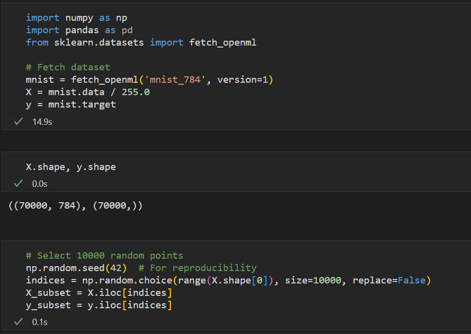

   1. **Load and Process the Data**

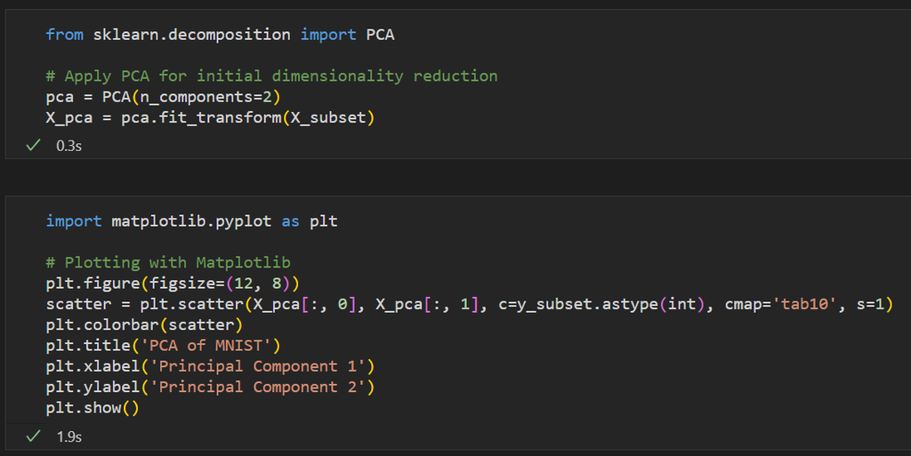

   2. **Apply PCA with 2 axes**

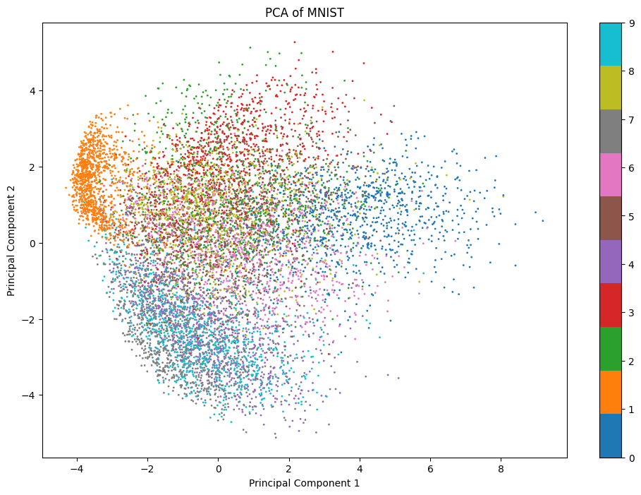

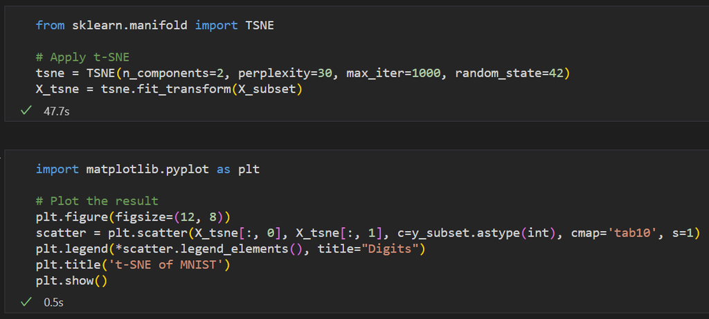

3. **Apply t-SNE with 2 components**

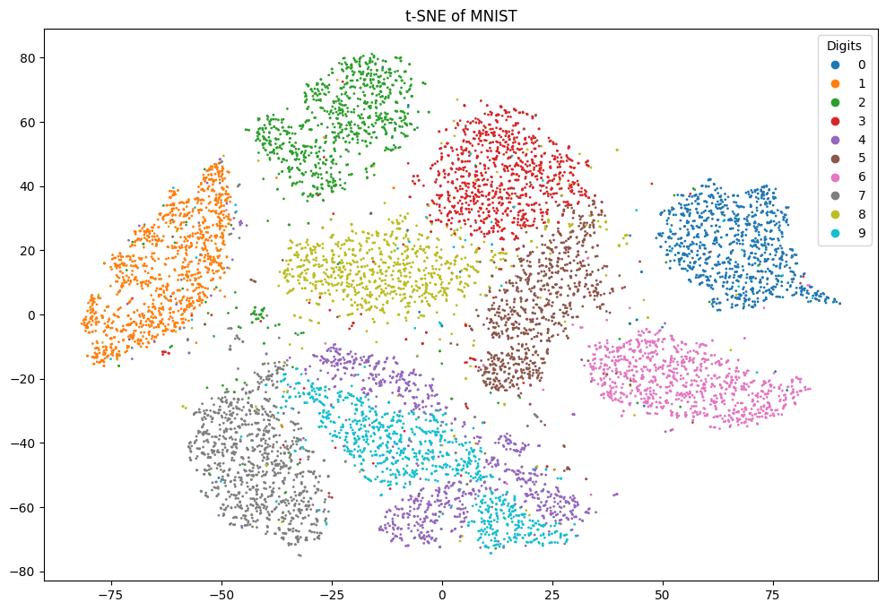

It is evident that t-SNE was much more efficient than PCA in capturing non-linear relationship in the data, leading to better classification.

7. **Some important aspects of t-SNE**
1. **Interpreting Clusters:** t-SNE can reveal clusters and local structures very effectively. However, the distance between clusters or the relative position of clusters in the plot may not have a meaningful interpretation. Avoid over-interpreting global relationships.
2. **Axes have no meaning:** Axes in t-SNE has no interpretable meaning, that is why t-SNE is only used for visualization and not for prediction.
3. **Perplexity Matters:** Perplexity is a crucial hyperparameter in t-SNE. It roughly corresponds to the number of effective nearest Neighbors, i.e. the density. There’s no one-size-fits-all value; different values can reveal different structures, so experimentation with a range of values is necessary. Common values are between 5 and 50.
4. **Reproducibility:** Due to its stochastic nature, leads to different results each time it runs.
5. **Scaling the Data:** Pre-processing steps like scaling or normalizing the data, especially if features are on different scales, can have a significant impact on the results of t-SNE.
6. **Curse of Dimensionality:** t-SNE can mitigate but not completely overcome the curse of dimensionality. Very high-dimensional data might require other steps, like initial dimensionality reduction with PCA, before applying t-SNE which has been known to reduce the noise in large datasets.
7. **Learning Rate and Number of Iterations:** Beyond perplexity, other parameters like the learning rate and the number of iterations also impact the results. A learning rate that’s too high or too low can lead to poor embeddings, and insufficient iterations might mean the algorithm doesn’t fully converge.
8. **Advantages and Disadvantages**

> **Advantages**  
> • If done correctly, can give very intuitive visualizations as it preserves the local structure of the data in the lower dimensions

> **Disadvantages**  
> • Computationally Expensive  
> • Not very good at preserving global structure  
> • Sensitive to hyperparameters  
> • Can get stuck in local minima  
> • Interpretation is challenging
9. **Applications**
- t-SNE has extensive applications across diverse domains due to its exceptional ability to reveal hidden patterns in complex datasets. In bioinformatics, researchers employ t-SNE to analyze gene expression data, uncovering previously unknown cell subpopulations and identifying relationships between different cell types and states. The technique has proven particularly valuable in single-cell RNA sequencing analysis, where it helps visualize cellular heterogeneity and developmental trajectories.
- The commercial sector uses t-SNE for various practical applications. E-commerce companies utilize t-SNE to analyze customer behavior patterns, mapping high-dimensional feature spaces that include browsing history, purchase patterns, and product preferences to create targeted marketing campaigns. In cybersecurity, t-SNE enables the detection of anomalous network behavior by visualizing high-dimensional attack patterns and distinguishing them from benign traffic profiles.
- Healthcare institutions implement t-SNE for analyzing patient data, correlating clinical measures with genomic information to improve diagnostic accuracy and develop personalized treatment plans. The visualization capabilities of t-SNE facilitate the identification of patient subgroups with similar characteristics, enabling more effective medical interventions.
- t-SNE has become an essential tool for understanding deep neural network behavior. Researchers use t-SNE to visualize network activations in different layers, providing insights into how networks transform input data as it progresses through the architecture. This application helps identify potential issues with input data and understand which observations networks classify incorrectly.

-------------------------------------------------------------------------------------------------------------------------------------

1. https://en.wikipedia.org/wiki/T-distributed_stochastic_neighbor_embedding
2. Research Paper- https://www.jmlr.org/papers/volume9/vandermaaten08a/vandermaaten08a.pdf
3. Blog 1 — https://distill.pub/2016/misread-tsne/
4. Blog 2 — https://colah.github.io/posts/2014-10-Visualizing-MNIST/
5. https://youtu.be/MnRskV3NY1k (Tübingen Machine Learning)
6. https://www.youtube.com/watch?v=NEaUSP4YerM (StatQuest with Josh Starmer)
7. [Mastering t-SNE, Medium](https://medium.com/@sachinsoni600517/mastering-t-sne-t-distributed-stochastic-neighbor-embedding-0e365ee898ea)